# (2017-fordgobike-tripdata)

## by (Wessam Hamdy)

## Investigation Overview

> In this investigation of the Ford GoBike dataset, I wanted to find the most and the least time of rides happen and look at the most common user type and it's behaviors

## Dataset Overview

> This dataset includes information about individual rides made in a bike-sharing system covering the greater San Francisco Bay area,includes 519,700 trips with 13 features such as stations, locations, time, and user attributes

## What is the duration of most rides?

> We note that most trips are approximately 10 minutes

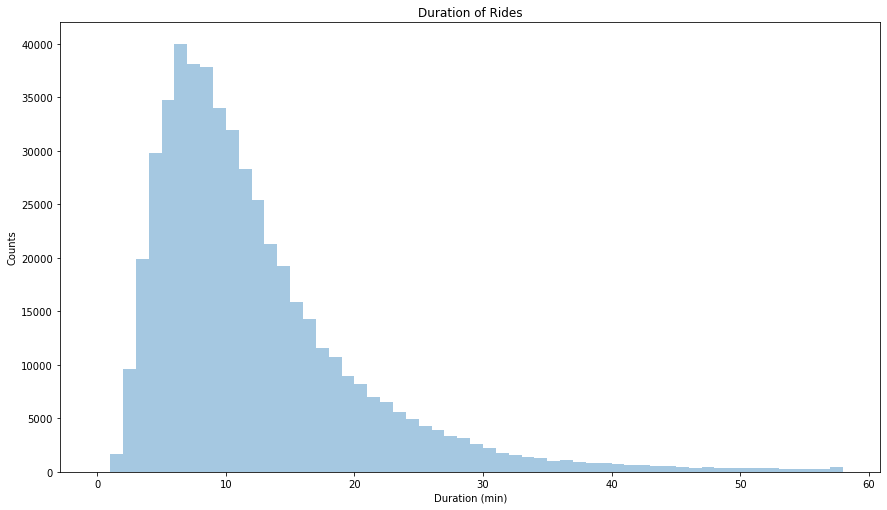

## The most 10 popular start and end stations.

> San Francisco Ferry Building (Harry Bridges Plaza) and The Embarcadero at Sansome St are the most common start station

> San Francisco Caltrain (Townsend St at 4th St) and San Francisco Ferry Building (Harry Bridges Plaza) are the most common end station

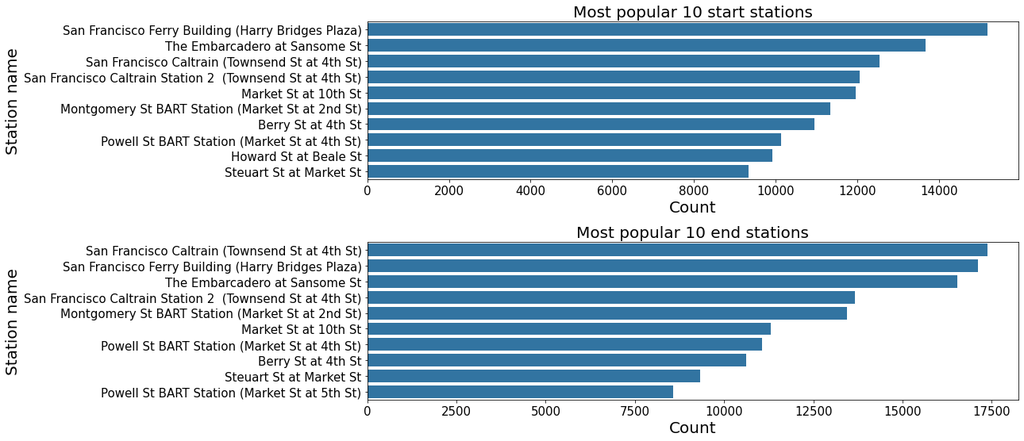

## The most common user type.

> 21.3% of the riders are Custmoers while 78.7% are Subscriber, so most of users are subscribers

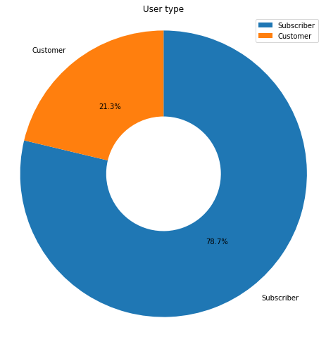

## What are the most common days?

> Most of users prefer weekdays than weekends so Tuesday and Wednesday are the most common days, while Sunday is the least day

> Day 6 and 7 are the most common too, while 31 and 23 are the least

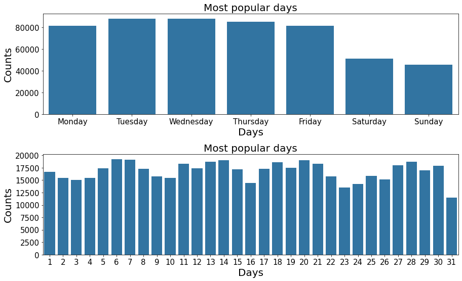

## What is the most common month?

> they do few trips in June, and almost of their trips are in September, October, November

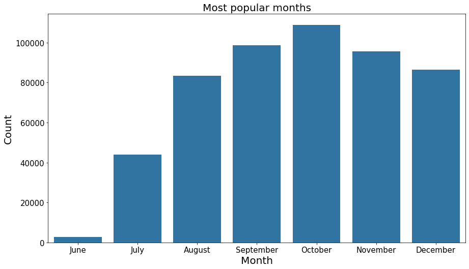

## What is the frequency of users type per hour?

> from 12 am to 6 am there is the least time, and It's obvious because they are sleeping

> the most frequency of Subscribers is 8-9 AM and 5-6 PM, the two intervals almost equal, i think because these are working hours, while Customers prefer doing trips from 8 AM to 6 PM

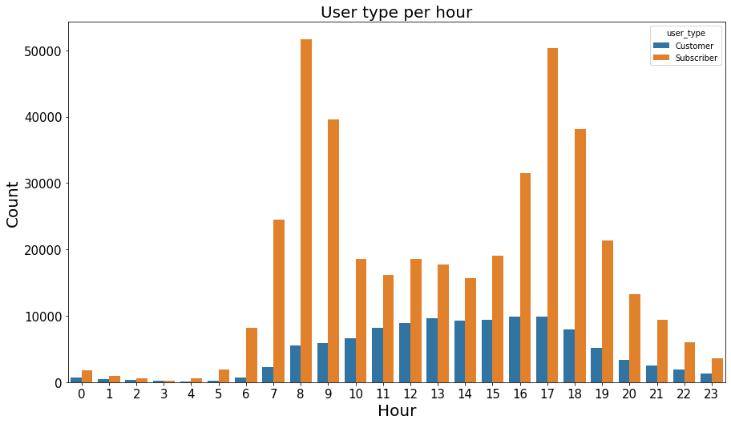

## What is the frequency of users type per day?

> the frequency of the Customer type on weekdays is almost equal, but they prefer doing trips on weekends

> the frequency of the Subscriber type on weekdays is almost equal too and their trips almost in weekdays

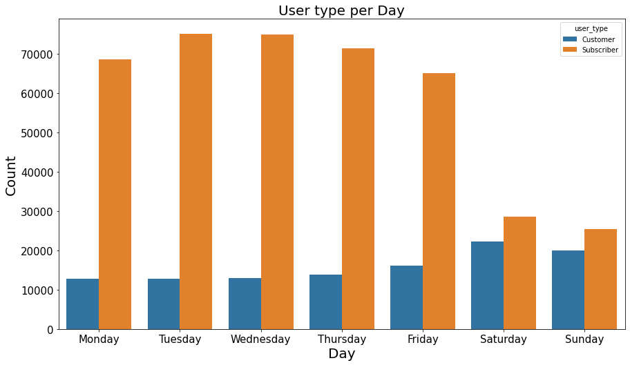

## What is the most day during each month that most trips take place?

> the most common days in June are Thursday and Friday, they almost equal, and we can notice they did not ride in the other days they just ride in these three days

> the most common days in July is Monday

> the most common days in August are Tuesday, Wednesday and Thursday they are almost equal

> the most common day in September is Friday

> the most common days in October are Monday and Tuesday they are almost equal

> the most common days in November is Wednesday

> the most common days in December is Friday

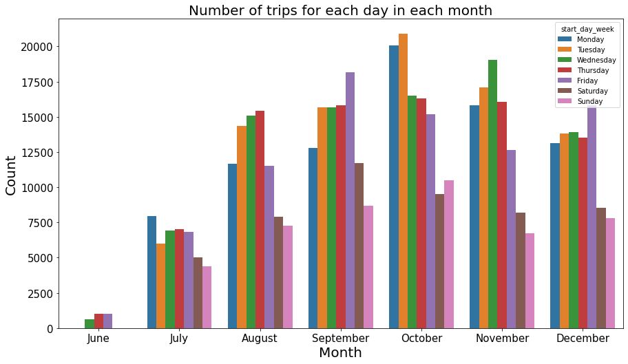

## What is the most common hours for each user in each day?

> Customers prefer weekends afternoon hours, while Subscribers prefer weekdays specialy 8 AM and 5 PM

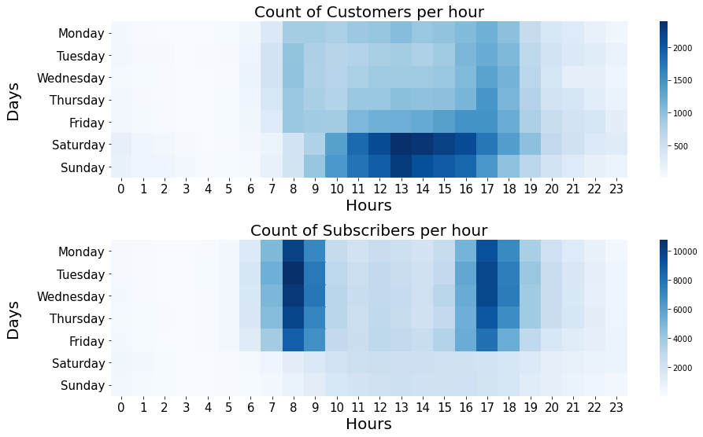